# ECo 602 - Analysis of Environmental Data

# Functions 5: Other Functions

## subset()

I can subset data using the `subset()` function. The first argument that goes in is the name of the data frame. The second is the condition you want to subset.

```r
# Earlier I created a data frame called "dat_1" and I will use that as an example here. Let's say I am interested in subsetting all numbers less than 3, my code would look like this:

subset(dat_1, subset = numbers < 3)
```

```
##   letters numbers
## 1       A       1
## 2       B       2
```

```r
# Now let's say I want to pick out all the rows where the numbers are more than 0. My code would look like this:

subset(dat_1, subset = numbers > 0)
```

```
##   letters numbers
## 1       A       1
## 2       B       2
## 3       C       3
```

```r
# Now let's say I want to select only the row containing the letter "A" in the column called letters. For that I can use a double equals sign like presented below.

subset(dat_1, letters == "A")
```

```
##   letters numbers
## 1       A       1
```

## Library() and require()

The functions `library()` and `require()` allow the user to load and attach packages. In order to load and read a package, a user must first install it. A readily available package that can be downloaded on anyone’s computer is the palmer penguin package. To install it the user can use the `install.packages()` function with the name of the package: “palmerpenguins”

one the package is installed, the user can now load the package into R’s environment we can use either the `require()` function of the `library()` function

- Using `require()`

```r
require(palmerpenguins)
```

- Using `library()`

```r
library(palmerpenguins)
```

## read.csv()

We can use the `read.csv()` function to read data files and create a data frame from it. One simple way to work with csv files on your computer is to first download and install the `here` package from R which allows you to simply locate files on your computer.

```r
# Reading the package into R's environment using the `require()` function followed by the location of the csv file. On this computer, the csv file has been downloaded and placed in a folder called "data".

require("here")
here("data", "hab.sta (2).csv")
```

```
## [1] "C:/Users/Randhir/Desktop/ECo_602_2020/data/hab.sta (2).csv"
```

```r
# Loading the data into a data frame

dat_habitat <- read.csv(here("data", "hab.sta (2).csv"))

# Preview the data frame containing the csv

head(dat_habitat)
```

```
##   basin sub sta     lat     long elev slope aspect s.id s.edge p.edge p.edge.1
## 1     D  AL   1 4924418 437009.8  542    75     15    3      E      E      131
## 2     D  AL   2 4924430 437200.6  519    80    326    2      E      E      192
## 3     D  AL   3 4924416 437430.8  584    70    230    1      I      I        0
## 4     D  AL   4 4923998 437731.0  612    60    208    3      I      E      120
## 5     D  AL   5 4923999 437544.2  580    43    235    3      I      I        0
## 6     D  AL   6 4924008 437327.2  554    65     60    3      I      E      166
##   p.cwedge ba.con ba.hard ba.snag ba.tot ba.ratio snag.sml snag.ml snag.l
## 1       79      0       5       0      5        0        7       4      0
## 2      175     18       0      18     18      100       67      46     32
## 3        0      0       0       5      0       50       14      11      4
## 4        6      9      14       0     23       40        4       4      4
## 5        0     14       0       0     14      100        0       0      0
## 6        8      9       0       5      9      100       21       7      7
##   snag.dc1 snag.dc2 snag.dc4
## 1        4        0        4
## 2       28       21       18
## 3        0        4       11
## 4        0        0        4
## 5        0        0        0
## 6        7        0       14
```

# Part 2: Data Anaylsis

## Data Exporation

### Numerical Exploration

Putting the delomy data set into a dataframe

```r
require("here")
here("data", "delomys.csv")
```

```
## [1] "C:/Users/Randhir/Desktop/ECo_602_2020/data/delomys.csv"
```

```r
dat_delomys <- read.csv(here("data", "delomys.csv"))
```

Previewing the delomy data with the `head()` function

```r
head(dat_delomys)
```

```
##       X   genus         binomial body_mass body_length   age    sex longitude
## 1 27526 Delomys Delomys dorsalis      50.5         259 adult female -48.22950
## 2 27528 Delomys Delomys dorsalis      79.0         223 adult female -48.22950
## 3 27529 Delomys Delomys dorsalis      57.0         206 adult female -48.22950
## 4 27530 Delomys Delomys dorsalis      71.0         229 adult   male -48.22950
## 5 27533 Delomys Delomys dorsalis      56.0         105 adult   male -50.39215
## 6 27534 Delomys Delomys dorsalis      50.0         118 adult   male -50.39215
##    latitude status
## 1 -24.20256  alive
## 2 -24.20256  alive
## 3 -24.20256  alive
## 4 -24.20256  alive
## 5 -29.40807  alive
## 6 -29.40807   dead
```

Using `summary()` on body mass and body length data columns to display summary statistics

```r
# Using the `summary()` on body mass
summary(dat_delomys$body_mass)
```

```
##    Min. 1st Qu.  Median    Mean 3rd Qu.    Max.
##    5.00   35.00   43.00   44.06   54.00  105.00
```

```r
# using the `summary()` on body length
summary(dat_delomys$body_length)
```

```
##    Min. 1st Qu.  Median    Mean 3rd Qu.    Max.
##    49.0   106.0   116.0   114.7   124.0   265.0
```

Performing a test of normality on the body mass and length columns using the `shapiro.test()`

```r
# Shapiro test on body mass

shapiro.test(dat_delomys$body_mass)
```

```
##
##  Shapiro-Wilk normality test
##
## data:  dat_delomys$body_mass
## W = 0.99506, p-value = 4.33e-05
```

```r
# Shapiro test on body length

shapiro.test(dat_delomys$body_length)
```

```
##
##  Shapiro-Wilk normality test
##
## data:  dat_delomys$body_length
## W = 0.87609, p-value < 2.2e-16
```

### Graphical Exploration

Scatterplot of body mass and body length

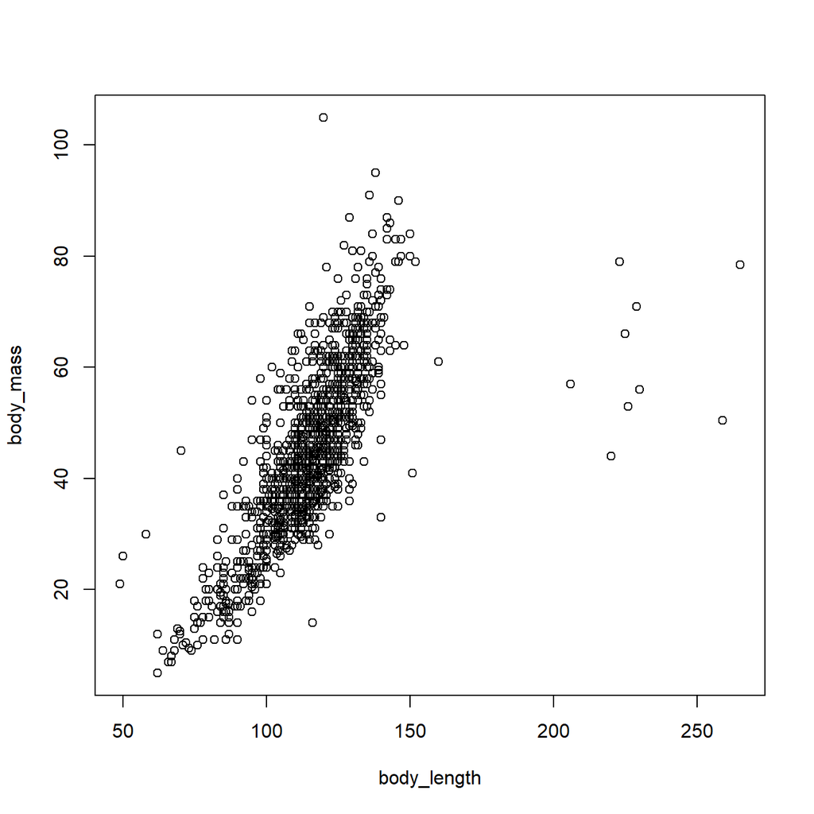

```r
plot(body_mass ~ body_length, data = dat_delomys)
```

Histogram of body mass

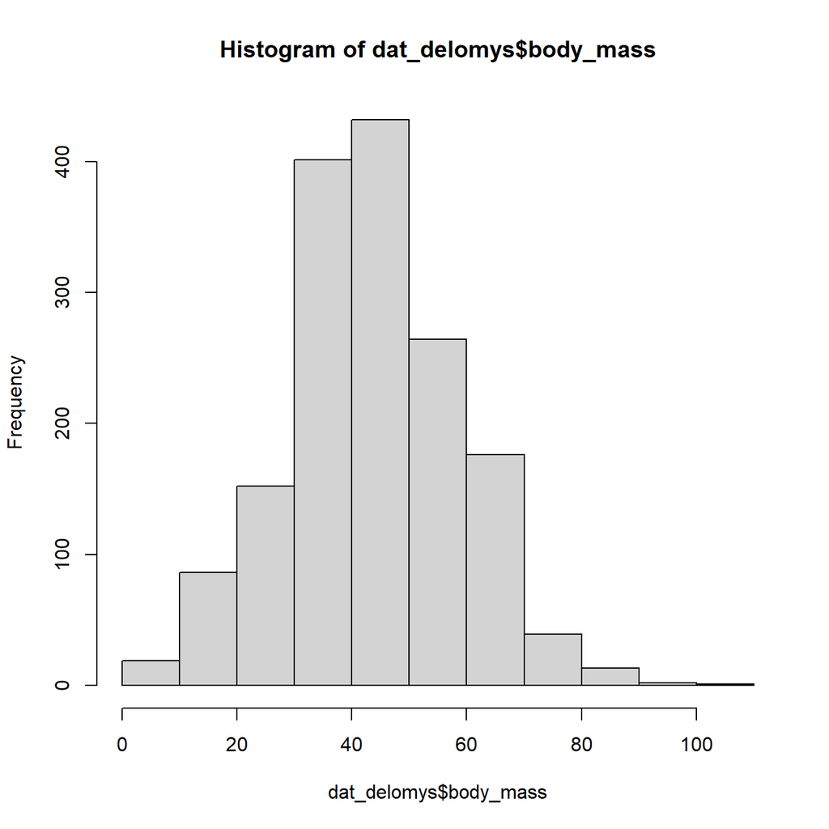

```r
hist(dat_delomys$body_mass)
```

Histogram of body length

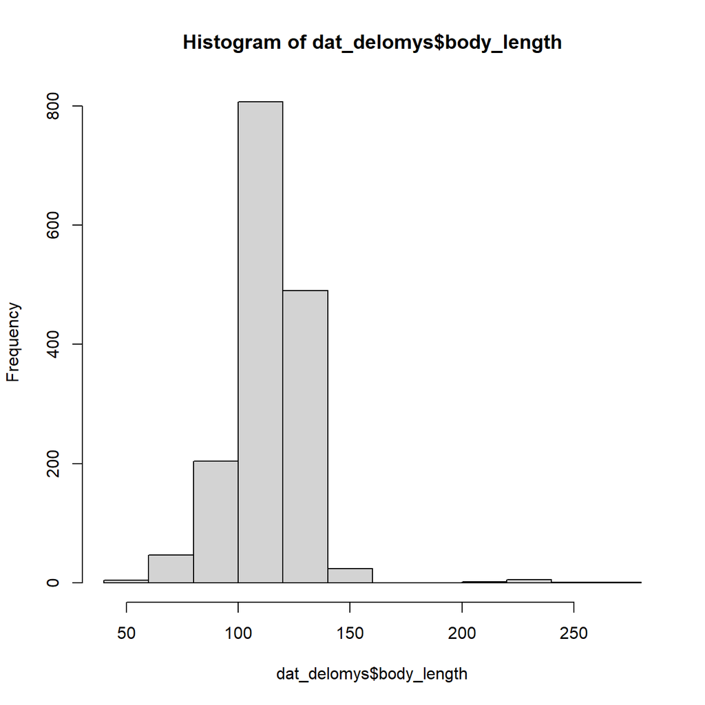

```r
hist(dat_delomys$body_length)
```

Conditional boxplot of body mass conditioned on species

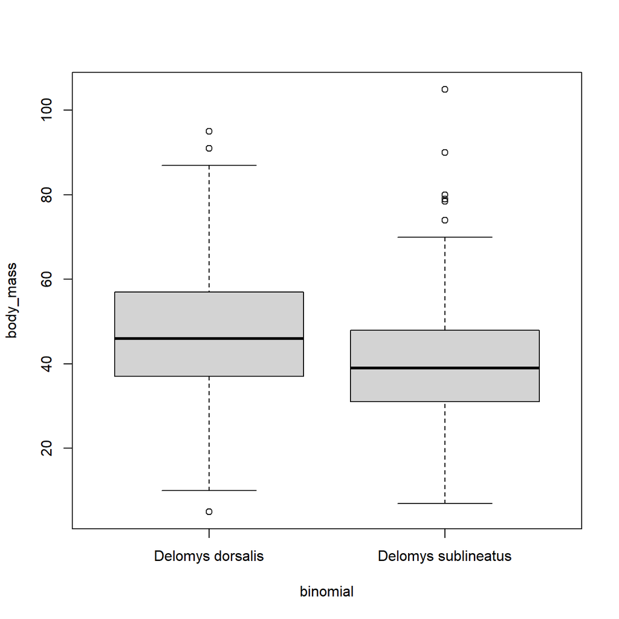

```r
boxplot(body_mass ~ binomial, data = dat_delomys)
```

Conditional boxplot of body mass conditioned on sex

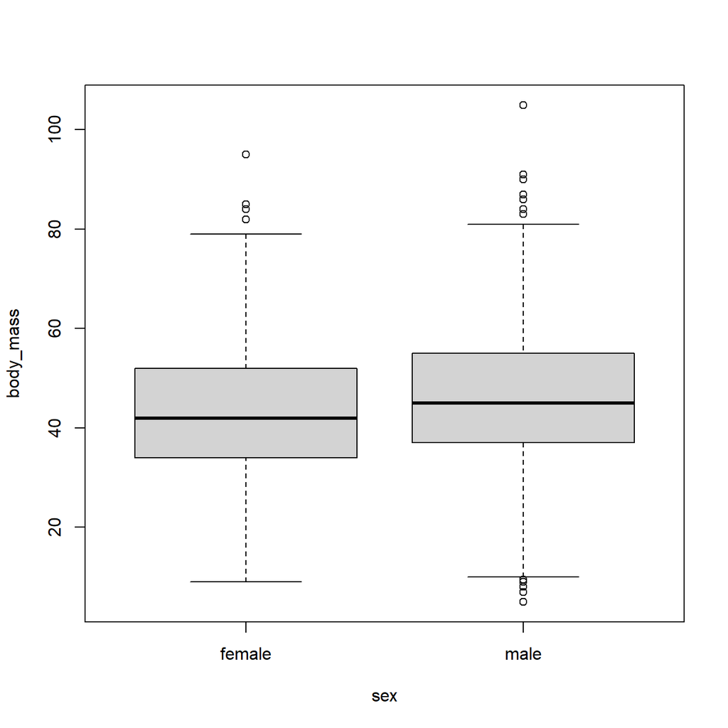

```r
boxplot(body_mass ~ sex, data = dat_delomys)
```

Conditional boxplot of body mass, conditioned on both species and sex

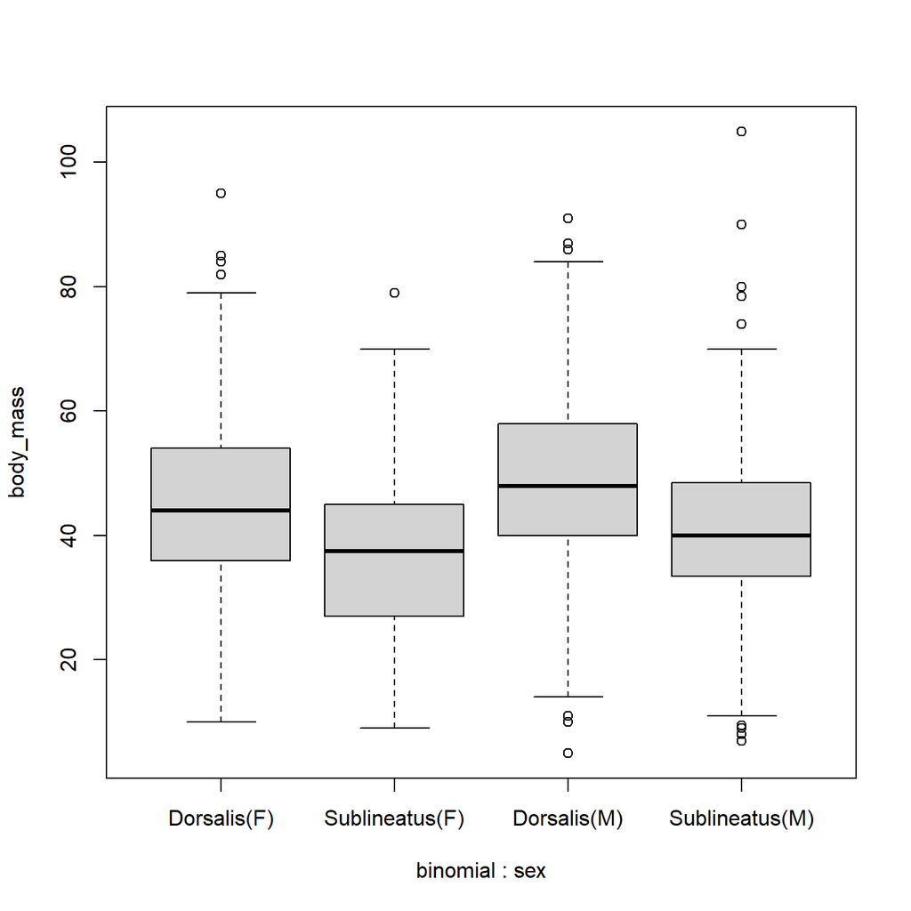

```r
boxplot(body_mass ~ binomial*sex, data = dat_delomys, names = c("Dorsalis(F)", "Sublineatus(F)", "Dorsalis(M)", "Sublineatus(M)"))
```

Questions to answer:

- Qualitatively describe the relationship between body mass and length. Does the relationship seen linear, curved or nonexistent? ANSWER: From examining the scatterplot of body mass and body length, the relationship appears linear with the exception of some outliers found for species with body lengths more than 200.
- Qualitatively describe the shapes of the histograms. Do the data appear normally-distributed? ANSWER: From examining the histogram of the body mass, it appears that body mass is normally distributed maybe slightly right skewed. Normally distributed data is when we see relative symmetry around the mean. Data that is found near the mean appears more frequent in the data set and the frequency decreases the farther from the mean we get. Similarly, body length also seems to be normally distributed however there is skewness toward body lengths that are more or equal to 100.
- Using both the histograms and normality tests do you think the (unconditioned) body masses and body length are normally-distributed? ANSWER: The shapiro test hypothesis is that the data are drawn from a normally-distributed population. Examining the results of the shapiro test on the body length and body mass columns, both p-values are incredibly small (less than an alpha level of 0.05) meaning we can reject this null. The unconditioned body mass and body lengths are not normally distributed. This is contrary to how the data visually looks as both the histograms of body mass and body lengths appear relatively normally distributed.
- Examine the conditional boxplots. Describe any graphical evidence you see for body mass differences based on species and/or sex. ANSWER: When examining this conditional box plot of body mass conditioned on species, it appears as though the Dorsalis species are generally heavier than the sublineatus species. For the boxplots of body mass conditioned on sex, it appears that females and males are almost the same weight with males just being slightly heavier (median is slightly higher than for the females). When we look at the boxplot containing the body mass conditioned on both species and sex, we see a clearer picture. The Dorsalis female species are heavier than the Sublineatus female species, and the Dorsalis male species are heavier than the Sublineatus male species. In general the Dorsalis species are heavier than the Sublineatus species and maes are just slightly heavier than females.

## Model Building

### Model Building

```r
# Fit model
fit1 <- lm(body_length ~ body_mass, data = dat_delomys)
fit2 <- lm(body_mass ~ sex, data = dat_delomys)
fit3 <- lm(body_mass ~ binomial, data = dat_delomys)
fit4 <- lm(body_mass ~ sex + binomial, data = dat_delomys)
fit5 <- lm(body_mass ~ sex * binomial, data = dat_delomys)

# Print results
fit1
```

```
##
## Call:
## lm(formula = body_length ~ body_mass, data = dat_delomys)
##
## Coefficients:
## (Intercept)    body_mass
##     76.1247       0.8755
```

```r
fit2
```

```
##
## Call:
## lm(formula = body_mass ~ sex, data = dat_delomys)
##
## Coefficients:
## (Intercept)      sexmale
##      42.711        2.784
```

```r
fit3
```

```
##
## Call:
## lm(formula = body_mass ~ binomial, data = dat_delomys)
##
## Coefficients:
##                 (Intercept)  binomialDelomys sublineatus
##                      46.752                       -7.683
```

```r
fit4
```

```
##
## Call:
## lm(formula = body_mass ~ sex + binomial, data = dat_delomys)
##
## Coefficients:
##                 (Intercept)                      sexmale
##                      45.070                        3.795
## binomialDelomys sublineatus
##                      -8.193
```

```r
fit5
```

```
##
## Call:
## lm(formula = body_mass ~ sex * binomial, data = dat_delomys)
##
## Coefficients:
##                         (Intercept)                              sexmale
##                            45.05546                              3.82809
##         binomialDelomys sublineatus  sexmale:binomialDelomys sublineatus
##                            -8.14174                             -0.09502
```

### Model Diagnostics

Checking to see whether our models fit the assumption of normality of the residuals using the graphical approach

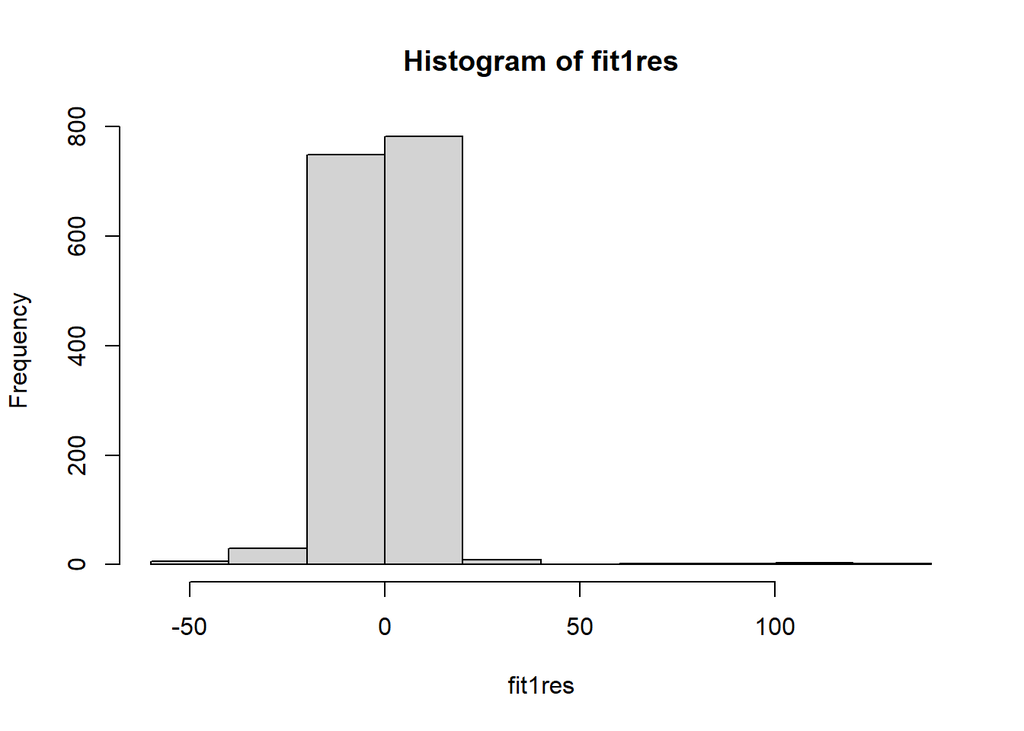

```r
# Creating the residuals
fit1res <- residuals(fit1)
fit2res <- residuals(fit2)
fit3res <- residuals(fit3)
fit4res <- residuals(fit4)
fit5res <- residuals(fit5)

#create histograms of the residuals
hist(fit1res)
```

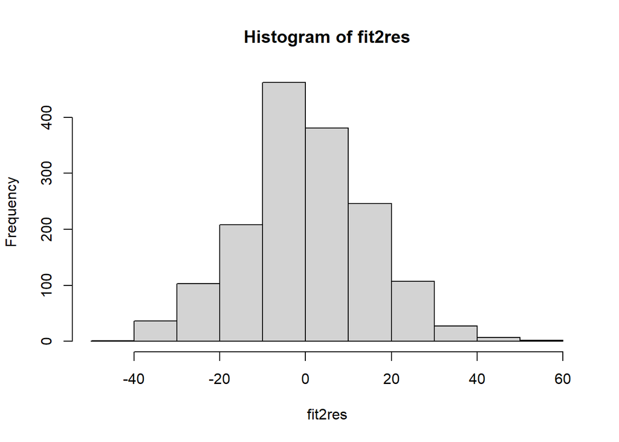

```r
hist(fit2res)
```

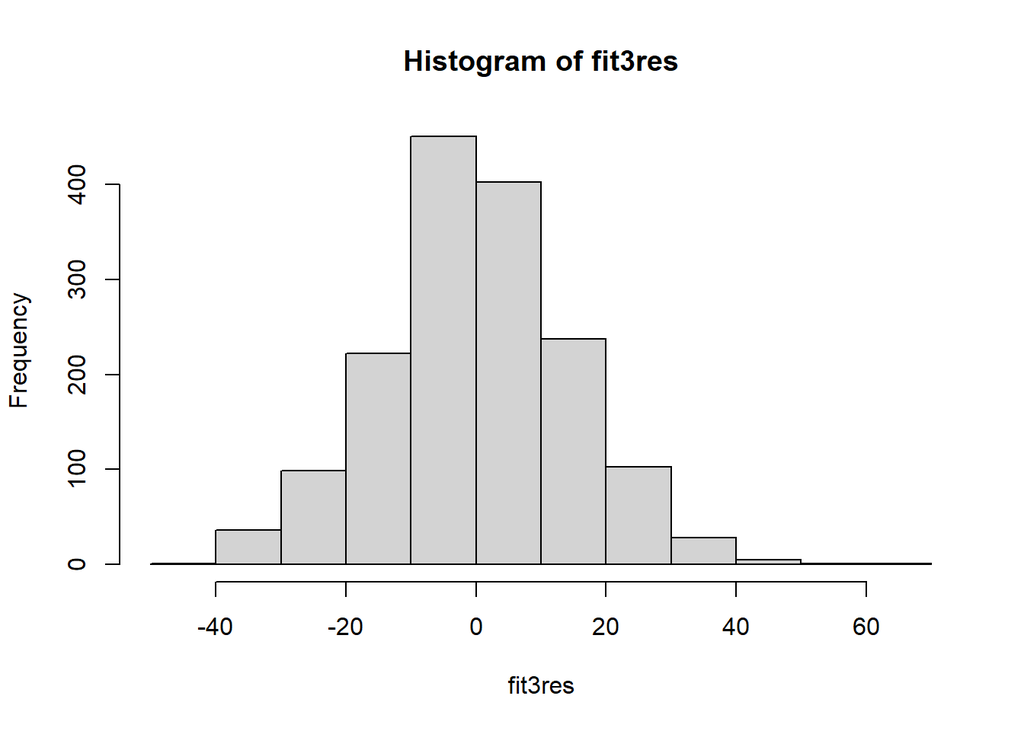

```r
hist(fit3res)
```

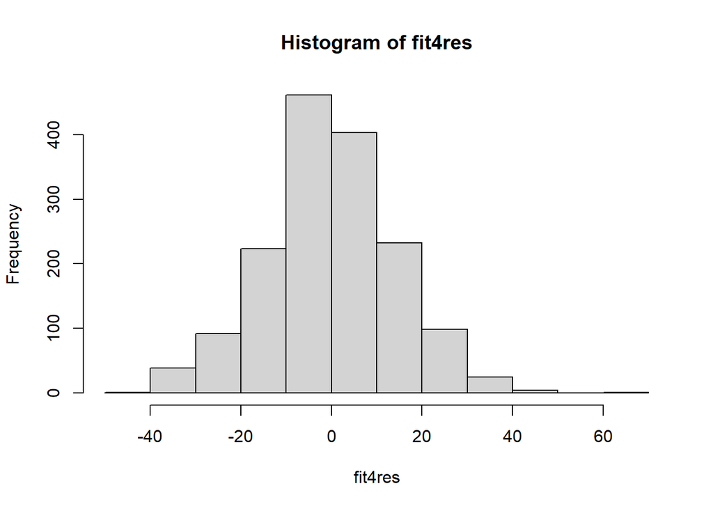

```r
hist(fit4res)
```

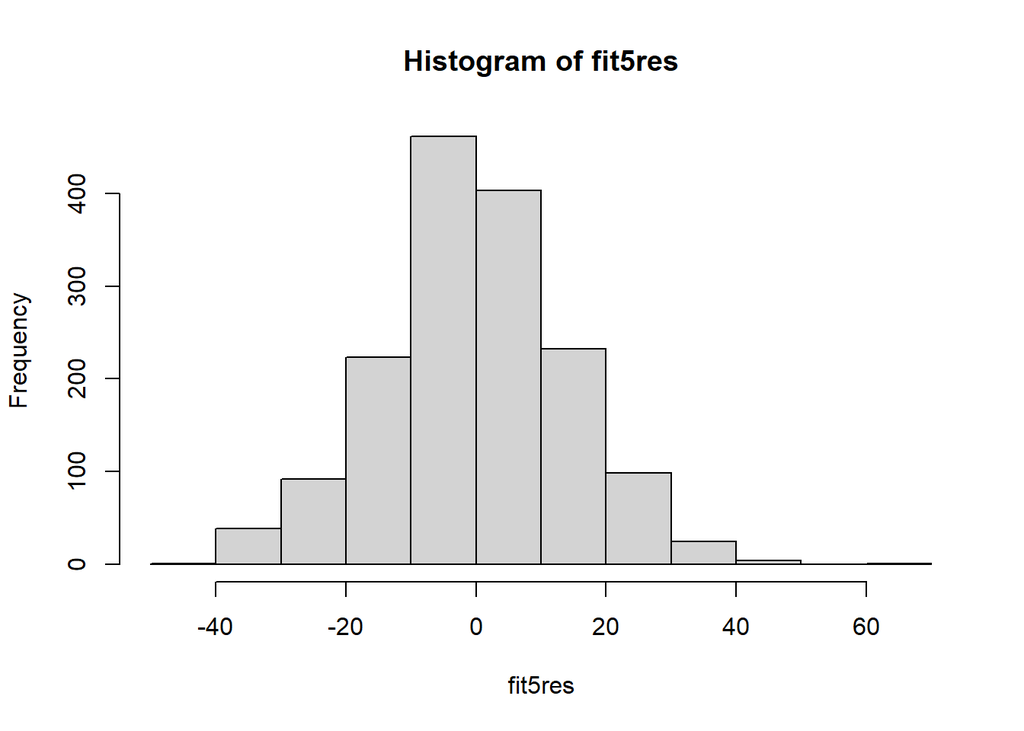

```r
hist(fit5res)
```

Using the `shapiro.test()` function on each model to test the null hypothesis that the residuals are drawn from a normally-distributed population

```r
shapiro.test(fit1res)
```

```
##
##  Shapiro-Wilk normality test
##
## data:  fit1res
## W = 0.73462, p-value < 2.2e-16
```

```r
shapiro.test(fit2res)
```

```
##
##  Shapiro-Wilk normality test
##
## data:  fit2res
## W = 0.99563, p-value = 0.0001541
```

```r
shapiro.test(fit3res)
```

```
##
##  Shapiro-Wilk normality test
##
## data:  fit3res
## W = 0.99535, p-value = 8.103e-05
```

```r
shapiro.test(fit4res)
```

```
##
##  Shapiro-Wilk normality test
##
## data:  fit4res
## W = 0.99525, p-value = 6.805e-05
```

```r
shapiro.test(fit5res)
```

```
##
##  Shapiro-Wilk normality test
##
## data:  fit5res
## W = 0.99526, p-value = 6.816e-05
```

Answers to questions:

What do you conclude about residual normality based on the numerical and graphical diagnostics? ANSWER: Residual are not normally distributed across all models based on the results of the shapiro test. Even though the histograms appear that the residuals are normally distributed, the results of our shapiro test point other wise (very low p-values, ess than an alpha value of 0.05).

Are violations of the normality assumptions equally severe for all the models? ANSWER: The p values are not identical for all five models however all p values are substantially less than the alpha value of 0.05. The lowest p value is observed for model 1 with a p value of 2.2e-16 and the highest is for model 2 (0.0001541).

### Model intepretation

Printing out coefficient table

```r
knitr::kable(coef(summary(fit1)))
```

|  | Estimate | Std. Error | t value | Pr(>\|t\|) |
| --- | --- | --- | --- | --- |
| (Intercept) | 76.1246565 | 0.9158120 | 83.12258 | 0 |
| body_mass | 0.8754988 | 0.0196905 | 44.46298 | 0 |

```r
knitr::kable(coef(summary(fit2)))
```

|  | Estimate | Std. Error | t value | Pr(>\|t\|) |
| --- | --- | --- | --- | --- |
| (Intercept) | 42.711465 | 0.5288929 | 80.756355 | 0.0000000 |
| sexmale | 2.784133 | 0.7456117 | 3.734024 | 0.0001951 |

```r
knitr::kable(coef(summary(fit3)))
```

|  | Estimate | Std. Error | t value | Pr(>\|t\|) |
| --- | --- | --- | --- | --- |
| (Intercept) | 46.752427 | 0.4499933 | 103.89582 | 0 |
| binomialDelomys sublineatus | -7.683058 | 0.7604562 | -10.10322 | 0 |

```r
knitr::kable(coef(summary(fit4)))
```

|  | Estimate | Std. Error | t value | Pr(>\|t\|) |
| --- | --- | --- | --- | --- |
| (Intercept) | 45.070355 | 0.5556429 | 81.113891 | 0e+00 |
| sexmale | 3.795395 | 0.7259609 | 5.228099 | 2e-07 |
| binomialDelomys sublineatus | -8.193492 | 0.7609985 | -10.766764 | 0e+00 |

```r
knitr::kable(coef(summary(fit5)))
```

|  | Estimate | Std. Error | t value | Pr(>\|t\|) |
| --- | --- | --- | --- | --- |
| (Intercept) | 45.0554562 | 0.6052973 | 74.4352459 | 0.0000000 |
| sexmale | 3.8280908 | 0.8966667 | 4.2692460 | 0.0000208 |
| binomialDelomys sublineatus | -8.1417394 | 1.1281046 | -7.2171847 | 0.0000000 |
| sexmale:binomialDelomys sublineatus | -0.0950187 | 1.5285856 | -0.0621612 | 0.9504424 |

Printing out ANOVA tables

```r
knitr::kable(anova(fit1))
```

|  | Df | Sum Sq | Mean Sq | F value | Pr(>F) |
| --- | --- | --- | --- | --- | --- |
| body_mass | 1 | 269388.9 | 269388.9086 | 1976.957 | 0 |
| Residuals | 1583 | 215706.6 | 136.2645 | NA | NA |

```r
knitr::kable(anova(fit2))
```

|  | Df | Sum Sq | Mean Sq | F value | Pr(>F) |
| --- | --- | --- | --- | --- | --- |
| sex | 1 | 3061.678 | 3061.6779 | 13.94294 | 0.0001951 |
| Residuals | 1578 | 346507.131 | 219.5863 | NA | NA |

```r
knitr::kable(anova(fit3))
```

|  | Df | Sum Sq | Mean Sq | F value | Pr(>F) |
| --- | --- | --- | --- | --- | --- |
| binomial | 1 | 21289.68 | 21289.6805 | 102.0751 | 0 |
| Residuals | 1583 | 330164.45 | 208.5688 | NA | NA |

```r
knitr::kable(anova(fit4))
```

|  | Df | Sum Sq | Mean Sq | F value | Pr(>F) |
| --- | --- | --- | --- | --- | --- |
| sex | 1 | 3061.678 | 3061.6779 | 14.95838 | 0.0001144 |
| binomial | 1 | 23727.134 | 23727.1342 | 115.92320 | 0.0000000 |
| Residuals | 1577 | 322779.997 | 204.6798 | NA | NA |

```r
knitr::kable(anova(fit5))
```

|  | Df | Sum Sq | Mean Sq | F value | Pr(>F) |
| --- | --- | --- | --- | --- | --- |
| sex | 1 | 3.061678e+03 | 3.061678e+03 | 14.948932 | 0.0001150 |
| binomial | 1 | 2.372713e+04 | 2.372713e+04 | 115.849977 | 0.0000000 |
| sex:binomial | 1 | 7.913846e-01 | 7.913846e-01 | 0.003864 | 0.9504424 |
| Residuals | 1576 | 3.227792e+05 | 2.048091e+02 | NA | NA |

## Model Interpretation

### Body Length

Body length Questions:

What is the magnitude of the mass/length relationship? ANSWER: The magnitude of the relationship is the slope which is 0.8754988

What is the expected body length of an animals that weighs 100g? ANSWER: It would be 163.674536cm

What is the expected body length of an animal that weighs 0g? ANSWER: This would be the intercept which is 76.1246565cm

### Body Mass: Model Coefficients

Body mass questions:

What is the base level for sex? ANSWER: female

What is the base level for binomial? ANSWER: Delomys dorsalis

Which sex is heavier? ANSWER: male

Which species is heavier? ANSWER: Delomys dorsalis

### Body Mass: ANOVA

ANOVA related questions:

Are sex and species significant predictors for body mass? ANSWER: Yes, the p-values are smaller than the alpha value of 0.05

Is there a significant interaction? ANSWER: There is not a significant interaction

Does the significance (as measured by p-value) of either of the main effects (sex and species) differ much between the single-predictor models, the additive models, and the interactive models? ANSWER: They do not. In both the p-values are significantly less than an alpha value of 0.05 and in general, the p-value is relatively close for sex across the additive and interactive models and the same thing for species.

## Model Comparison: Body Mass

We can use the AIC criterion to compare the models

```r
AIC(fit2)
```

```
## [1] 13006.8
```

```r
AIC(fit3)
```

```
## [1] 12966.36
```

```r
AIC(fit4)
```

```
## [1] 12896.73
```

```r
AIC(fit5)
```

```
## [1] 12898.72
```

Questions regarding the AIC values for the four body mass models

Which two models have the lowest AIC? ANSWER: Model 4 (12896.73) and Model 5 (12898.72)

Which of the two models with lowest AIC scores would you select? ANSWER: Both model 4 and Model 5 have low AIC scores however Model 4 is an additive model and Model 5 is a factorial model that considers interactions. I would choose the additive model. The interaction between them is not an important factor making the difference. There is a high p-value for the interaction term (not significant) so it wouldn’t be deciding for the model and therefore, we can use a simpler model (the additive model) to explain the data.